# IODS course project

Kuura Variskallio

# Introduction to Open Data Science - Course Project

# About the project

*Ruminations about the Introduction to Open Data Science (IODS) 2021*

## Feelings

The course `Introduction to Open Data Science (IODS)` feels like a good introduction to the **R-Rstudio-git** pipeline advocating for reproducible well-documented research.

Challenges may arise due to

- various backgrounds of the students
- technological hurdles

## Outcomes

I hope the course will generate mindsets favoring *open research* equipped with *technical skills* to produce good research output.

I hope to learn not only technical skills but also ways to endorse open data science.

## Where to find the course

I found the course in Sisu. Apparently it is also found in the [MOOC](https://mooc.helsinki.fi) platform.

## Repo

A fork of the course can be found at my [repo](https://github.com/kuuravar/IODS-project).

# Week 2 - Simple linear regression

```r
date()
```

```
## [1] "Sat Dec 11 23:10:36 2021"
```

## Introduction

This week, we are analyzing and modeling a survey data concerning the approaches to learning. Description of the data can be found [here](https://www.mv.helsinki.fi/home/kvehkala/JYTmooc/JYTOPKYS3-meta.txt) and [here](https://www.mv.helsinki.fi/home/kvehkala/JYTmooc/JYTOPKYS2-meta.txt).

The data has been preprocessed to include variables on gender, age, attitude, exam points, and scores on deep, surface and strategic questions.

## Dataset

Begin by loading the analysis data. Let’s use the “official” csv-file; an R script to produce the wrangled data is in the [repo](https://github.com/kuuravar/IODS-project).

```r
# read in the data
learning2014 <- read.csv("http://s3.amazonaws.com/assets.datacamp.com/production/course_2218/datasets/learning2014.txt", header = TRUE, sep = ",")

dim(learning2014)
```

```
## [1] 166   7
```

There are 166 rows and 7 columns.

```r
str(learning2014)
```

```
## 'data.frame':    166 obs. of  7 variables:
##  $ gender  : chr  "F" "M" "F" "M" ...
##  $ age     : int  53 55 49 53 49 38 50 37 37 42 ...
##  $ attitude: num  3.7 3.1 2.5 3.5 3.7 3.8 3.5 2.9 3.8 2.1 ...
##  $ deep    : num  3.58 2.92 3.5 3.5 3.67 ...
##  $ stra    : num  3.38 2.75 3.62 3.12 3.62 ...
##  $ surf    : num  2.58 3.17 2.25 2.25 2.83 ...
##  $ points  : int  25 12 24 10 22 21 21 31 24 26 ...
```

The variables are mostly numeric. Gender is of character value, change it to factor.

```r
# change to factor
learning2014$gender <- as.factor(learning2014$gender)

summary(learning2014)
```

```
##  gender       age           attitude          deep            stra
##  F:110   Min.   :17.00   Min.   :1.400   Min.   :1.583   Min.   :1.250
##  M: 56   1st Qu.:21.00   1st Qu.:2.600   1st Qu.:3.333   1st Qu.:2.625
##          Median :22.00   Median :3.200   Median :3.667   Median :3.188
##          Mean   :25.51   Mean   :3.143   Mean   :3.680   Mean   :3.121
##          3rd Qu.:27.00   3rd Qu.:3.700   3rd Qu.:4.083   3rd Qu.:3.625
##          Max.   :55.00   Max.   :5.000   Max.   :4.917   Max.   :5.000
##       surf           points
##  Min.   :1.583   Min.   : 7.00
##  1st Qu.:2.417   1st Qu.:19.00
##  Median :2.833   Median :23.00
##  Mean   :2.787   Mean   :22.72
##  3rd Qu.:3.167   3rd Qu.:27.75
##  Max.   :4.333   Max.   :33.00
```

Seems like most of the students are female, age spans 17-55, exam points are between 7-33 and the question variables are capped at 5 (from documentation, on a scale 1-5).

## Graphical overview

Using GGlally::ggpairs, we can plot the distribution of the variables, correlation (with significance), boxplots and scatterplots stratified by the gender.

```r
library(GGally)
```

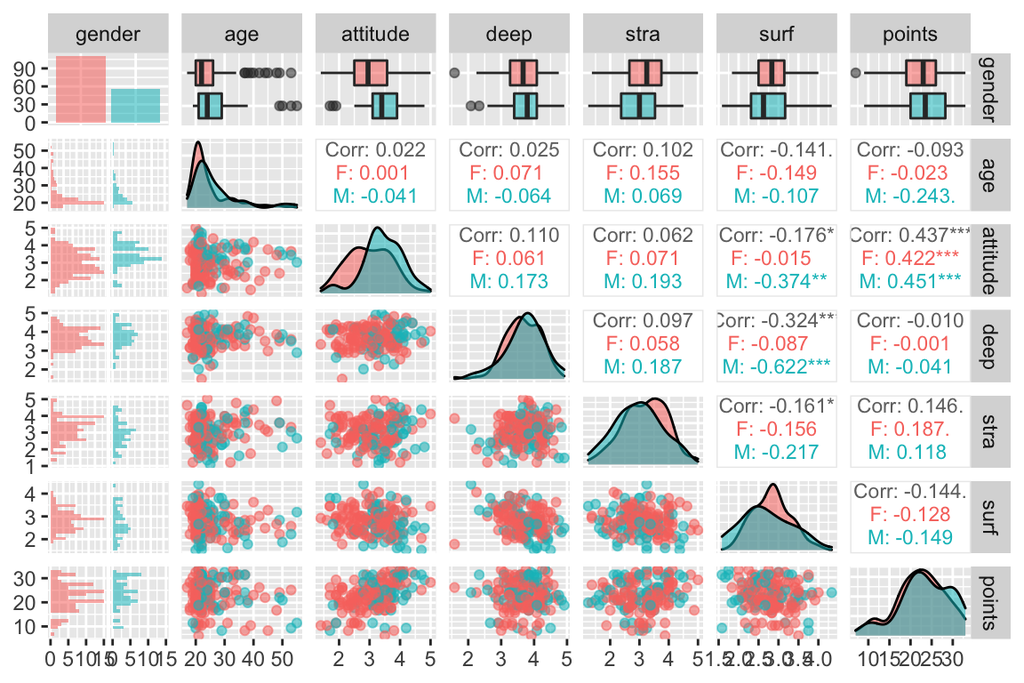

```r
library(ggplot2)

p <- ggpairs(learning2014, mapping = aes(col = gender, alpha = 0.3),
             lower = list(combo = wrap("facethist", bins = 20)),
             upper = list(continuous = wrap("cor", size = 3)))

p
```

We see that

- Most students are female
- Age is right skewed (more of smaller age)
- There is a positive correlation between `points` and `attitude`
- There is, as expected, a negative correlation between `surf` and `deep` questions
- There is a negative correlation between `surf` and `attitude`
- There is a negative correlation between `surf` and `stra` questions
- Distribution of the exam points is not perfectly normal (can be tested with e.g. stats::shapiro.test)

## Linear regression

For pedagogical reasons, let’s fit a simple multivariable linear regression first with four (instead of three; choosing three would not change the results) explanatory variables, ie. regress exam points on other variables. Choose variables based on their absolute correlation with the exam points.

```r
sort(abs(cor(learning2014[, -1])[, c("points")]))
```

```
##       deep        age       surf       stra   attitude     points
## 0.01014849 0.09319032 0.14435642 0.14612247 0.43652453 1.00000000
```

```r
model <- lm(points ~ attitude + stra + surf + age, data = learning2014)

summary(model)
```

```
##
## Call:
## lm(formula = points ~ attitude + stra + surf + age, data = learning2014)
##
## Residuals:
##      Min       1Q   Median       3Q      Max
## -17.8639  -3.2849   0.3086   3.4548  10.7028
##
## Coefficients:
##             Estimate Std. Error t value Pr(>|t|)
## (Intercept) 13.70644    3.96234   3.459 0.000694 ***
## attitude     3.38964    0.57041   5.942 1.68e-08 ***
## stra         0.93123    0.53986   1.725 0.086459 .
## surf        -0.76565    0.80258  -0.954 0.341524
## age         -0.09466    0.05346  -1.771 0.078502 .
## ---
## Signif. codes:  0 '***' 0.001 '**' 0.01 '*' 0.05 '.' 0.1 ' ' 1
##
## Residual standard error: 5.262 on 161 degrees of freedom
## Multiple R-squared:  0.2226, Adjusted R-squared:  0.2033
## F-statistic: 11.52 on 4 and 161 DF,  p-value: 2.987e-08
```

From the summary, the intercept is very significantly non-zero based on a t-test (H_0: intercept is zero, H_1: intercept is not zero) although the result is not very meaningful as e.g. age cannot be zero in this context.

The `attitude` variable has a very significant effect on the exam points (p-value about zero for a t-test for H_0: attitude has no effect on the slope when the other variables are kept constant, H_1: attitude has an effect). Variables `stra` and `age` are weakly significant or non-significant depending on the nomenclature (same test). Variable `surf` is not significant, let’s remove it and refit.

```r
model <- lm(points ~ attitude + stra + age, data = learning2014)

summary(model)
```

```
##
## Call:
## lm(formula = points ~ attitude + stra + age, data = learning2014)
##
## Residuals:
##      Min       1Q   Median       3Q      Max
## -18.1149  -3.2003   0.3303   3.4129  10.7599
##
## Coefficients:
##             Estimate Std. Error t value Pr(>|t|)
## (Intercept) 10.89543    2.64834   4.114 6.17e-05 ***
## attitude     3.48077    0.56220   6.191 4.72e-09 ***
## stra         1.00371    0.53434   1.878   0.0621 .
## age         -0.08822    0.05302  -1.664   0.0981 .
## ---
## Signif. codes:  0 '***' 0.001 '**' 0.01 '*' 0.05 '.' 0.1 ' ' 1
##
## Residual standard error: 5.26 on 162 degrees of freedom
## Multiple R-squared:  0.2182, Adjusted R-squared:  0.2037
## F-statistic: 15.07 on 3 and 162 DF,  p-value: 1.07e-08
```

Now all explanatory variables are significant with a 0.10 significance cutoff.

The F-test is significant, some of the variables are therefore associated with the response variable (have non-zero coefficient).

## Interpretation of the linear model

From the summary above, we see that as `attitude` increases by one, exam points increase by about 3.48 when other variables are kept constant. For `stra`, the value is about 1.00. Age seems to have a smaller effect, with an additional year decreasing exam points by around 0.09 if other variables do not change.

Multiple R-squared is 0.2182, meaning that the three explanatory variables account for approximately 22% variation in the exam points. This seems quite low and we should be careful when e.g. predicting exam points for new students with this model. The adjusted R-squared considers the number of explanatory variables and has here a similar, a bit smaller, value to the unadjusted R-squared.

## Diagnostics

Linear models carry assumptions that need to be verified. We use diagnostic plots for visual assessment.

### Residuals versus fitted

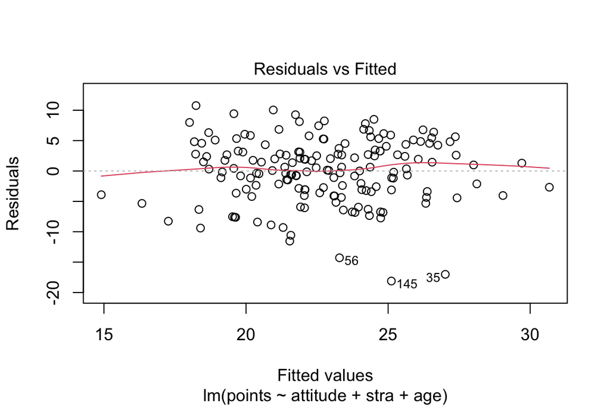

```r
# residuals vs fitted values
plot(model, which = 1)
```

There doesn’t seem to be a clear pattern (maybe visually somewhat of a funnel with decreasing variance but Breusch-Pagan test `car::ncvTest(model)` doesn’t detect heteroskedasticity) in the residuals versus fitted values in the sense that the variance in residuals is similar across the fitted values. Also, the variation is approximately symmetrical around zero. *Constant variance assumption* appears to be met. Linear model appears to be OK for the data.

Three outliers (set by `id.n` in plot.lm) are detected (rows 35, 56 and 145), let’s check them.

```r
print(learning2014[c(35, 56, 145), ])
```

```
##     gender age attitude     deep  stra     surf points
## 35       M  20      4.2 4.500000 3.250 1.583333     10
## 56       F  45      3.8 3.000000 3.125 3.250000      9
## 145      F  21      3.5 3.916667 3.875 3.500000      7
```

```
## [1] "attitude"
```

```
## [1] "stra"
```

```
## [1] "age"
```

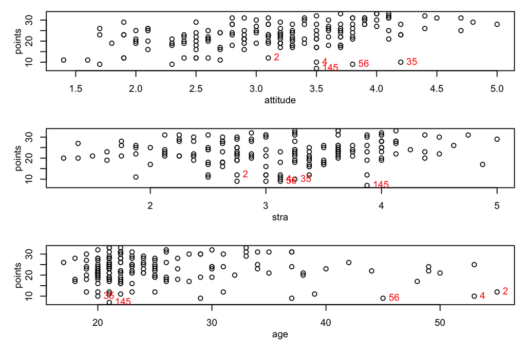

```r
annotate <- c(35, 56, 145, 4, 2)  # 4 and 2 for leverage below

# make the plot tighter
op <- par(mfrow=c(3, 1),
          mar = c(4, 4, 1, 1),
          mgp = c(2, 1, 0))

parameters <- c("attitude", "stra", "age")

for (param in parameters) {
  print(param)
  plot(learning2014[, param], learning2014$points,
       xlab = param, ylab = "points")

  text(learning2014[annotate, param],
       learning2014[annotate, "points"],
       annotate, pos = 4, col = "red")
}
```

```r
par(op) # return original par
```

It appears that here are the students that got low exam points despite having a high attitude value.

Plot boxplot for assessment of symmetry of the residual distribution.

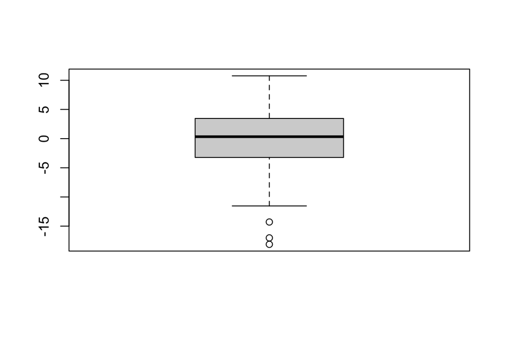

```r
boxplot(resid(model))
```

Does not seem too bad, but is not perfectly symmetric. QQ-plot will aid in deciding normality.

### QQ-plot

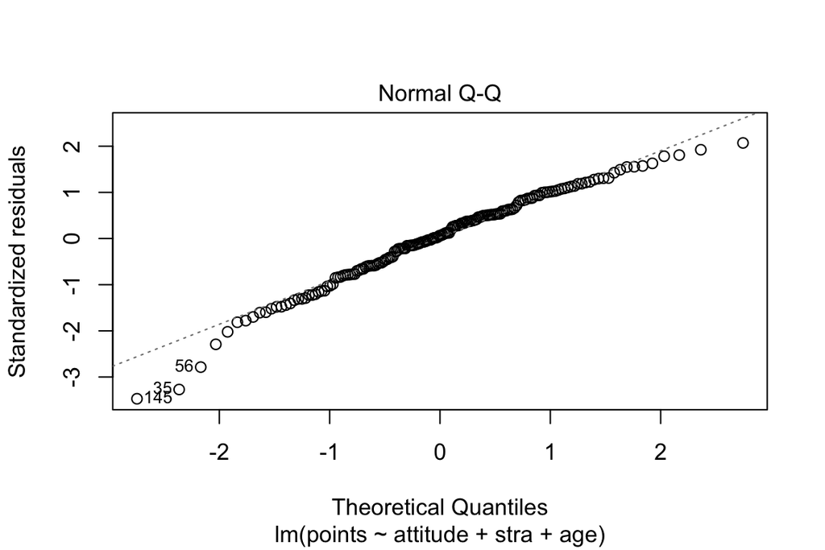

```r
# qq-plot
plot(model, which = 2)
```

Standardized residuals follow the linear pattern quite reasonably with the same outlier exceptions as above. Hence, there is no strong reason to suspect deviation from normality in the distribution of the residuals.

### Residuals versus leverage

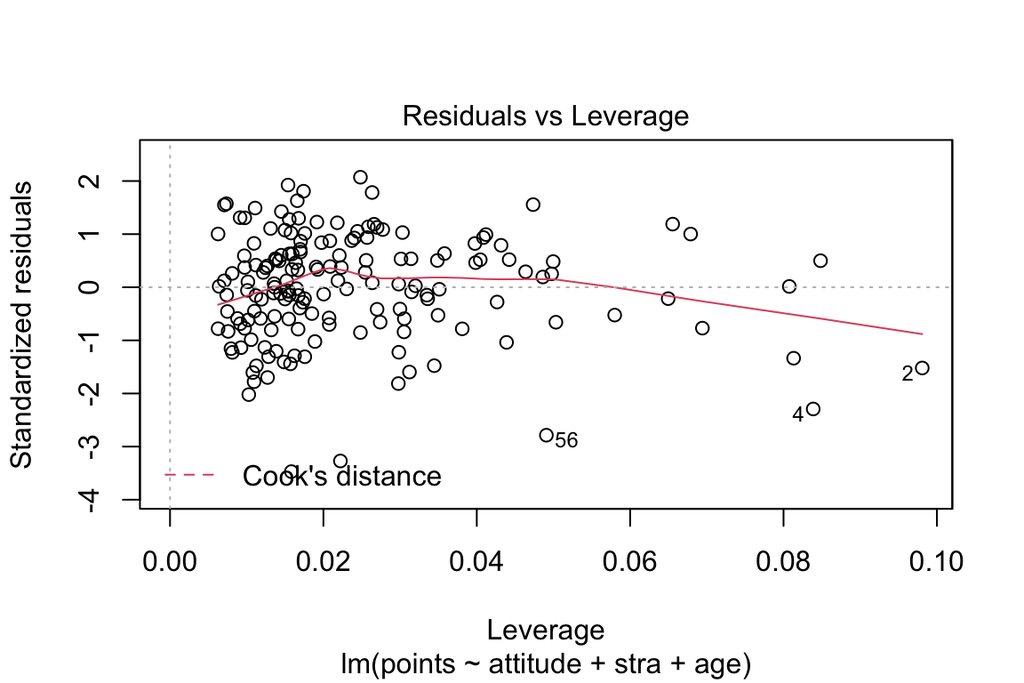

```r
# residuals vs. leverage
plot(model, which = 5)
```

Observations 2, 4 and 56 have been marked as outliers, they have relatively high influence of the regression line compared to other observations. We can rerun the model without these to see if the multiple R-squared is increased.

Cook’s distance is also low, supporting the notion that there are no outliers having a great effect on the linear fit.

```r
max(cooks.distance(model))
```

```
## [1] 0.1202162
```

```r
summary(lm(points ~ attitude + stra + age, data = learning2014[-c(2, 4, 56), ]))
```

```
##
## Call:
## lm(formula = points ~ attitude + stra + age, data = learning2014[-c(2,
##     4, 56), ])
##
## Residuals:
##     Min      1Q  Median      3Q     Max
## -17.822  -3.520   0.348   3.617  10.919
##
## Coefficients:
##             Estimate Std. Error t value Pr(>|t|)
## (Intercept)  8.38472    2.58566   3.243  0.00144 **
## attitude     3.64594    0.53695   6.790 2.11e-10 ***
## stra         0.84219    0.51066   1.649  0.10108
## age          0.01968    0.05677   0.347  0.72930
## ---
## Signif. codes:  0 '***' 0.001 '**' 0.01 '*' 0.05 '.' 0.1 ' ' 1
##
## Residual standard error: 5.008 on 159 degrees of freedom
## Multiple R-squared:  0.2419, Adjusted R-squared:  0.2276
## F-statistic: 16.91 on 3 and 159 DF,  p-value: 1.394e-09
```

Multiple R-square is indeed a bit better. However, removal of the outliers would have to be justified from the data (e.g. are these students somehow different).

### VIF

```r
library(car)
vif(model)
```

```
## attitude     stra      age
## 1.004083 1.014233 1.010865
```

Variance inflation factors are less than 10 (textbook), so there is no concern for collinearity.

### AIC

We can try automatic stepwise model selection by AIC criterion.

```r
library(MASS)
model.full <- lm(points ~ gender + age + attitude + deep + stra + surf,
                 data = learning2014)
stepAIC(model.full, direction = "both")
```

```
## Start:  AIC=558.36
## points ~ gender + age + attitude + deep + stra + surf
##
##            Df Sum of Sq    RSS    AIC
## - gender    1      0.11 4408.5 556.36
## - surf      1     47.79 4456.1 558.15
## - deep      1     49.00 4457.3 558.19
## <none>                  4408.3 558.36
## - stra      1     83.78 4492.1 559.48
## - age       1     87.88 4496.2 559.63
## - attitude  1    919.82 5328.2 587.82
##
## Step:  AIC=556.36
## points ~ age + attitude + deep + stra + surf
##
##            Df Sum of Sq    RSS    AIC
## - surf      1     47.69 4456.1 556.15
## - deep      1     49.11 4457.6 556.20
## <none>                  4408.5 556.36
## - stra      1     88.35 4496.8 557.66
## - age       1     90.16 4498.6 557.72
## + gender    1      0.11 4408.3 558.36
## - attitude  1    999.18 5407.6 588.27
##
## Step:  AIC=556.15
## points ~ age + attitude + deep + stra
##
##            Df Sum of Sq    RSS    AIC
## - deep      1     26.61 4482.8 555.14
## <none>                  4456.1 556.15
## + surf      1     47.69 4408.5 556.36
## - age       1     75.36 4531.5 556.93
## - stra      1    106.07 4562.2 558.05
## + gender    1      0.02 4456.1 558.15
## - attitude  1   1084.38 5540.5 590.30
##
## Step:  AIC=555.14
## points ~ age + attitude + stra
##
##            Df Sum of Sq    RSS    AIC
## <none>                  4482.8 555.14
## - age       1     76.62 4559.4 555.95
## + deep      1     26.61 4456.1 556.15
## + surf      1     25.20 4457.6 556.20
## - stra      1     97.64 4580.4 556.71
## + gender    1      0.01 4482.8 557.14
## - attitude  1   1060.72 5543.5 588.39
```

```
##
## Call:
## lm(formula = points ~ age + attitude + stra, data = learning2014)
##
## Coefficients:
## (Intercept)          age     attitude         stra
##    10.89543     -0.08822      3.48077      1.00371
```

The produced model is the same we derived earlier.

### Brute force

Finally, we can try to brute force all linear models of simple combination of explanatory variables.

```r
library(olsrr)
res <- olsrr::ols_step_all_possible(model.full)

res[order(res$adjr, decreasing = TRUE), ]
```

```
##    Index N                         Predictors     R-Square Adj. R-Square
## 62    57 5        age attitude deep stra surf 0.2311318189   0.207104688
## 33    22 3                  age attitude stra 0.2181719645   0.203693668
## 52    42 4             age attitude deep stra 0.2228135019   0.203504521
## 54    43 4             age attitude stra surf 0.2225665343   0.203251417
## 63    63 6 gender age attitude deep stra surf 0.2311510113   0.202137842
## 43    44 4           gender age attitude stra 0.2181729919   0.198748718
## 57    58 5      gender age attitude deep stra 0.2228168858   0.198529914
## 59    59 5      gender age attitude stra surf 0.2226046106   0.198311005
## 53    45 4             age attitude deep surf 0.2157221484   0.196236984
## 56    46 4            attitude deep stra surf 0.2154077956   0.195914822
## 17     7 2                      attitude stra 0.2048096617   0.195052725
## 38    23 3                 attitude deep stra 0.2096692889   0.195033535
## 34    24 3                  age attitude surf 0.2081990315   0.193536051
## 40    25 3                 attitude stra surf 0.2074263400   0.192749050
```

[output cut: 113 more lines]

By adjusted R-Square, it appears that the three variable model we used before fares very well compared to the full model. Attitude alone is also quite good in comparison and could be chosen by parsimony.

# Week 3 - Logistic regression

```r
date()
```

```
## [1] "Sat Dec 11 23:10:47 2021"
```

## Introduction

This week, we are analyzing and modeling data on two questionnaires related to student performance and alcohol consumption. Further description is available [here](https://archive.ics.uci.edu/ml/datasets/Student+Performance). Since the description is relevant for analysis we reprint it verbatim:

“*This data approach student achievement in secondary education of two Portuguese schools. The data attributes include student grades, demographic, social and school related features) and it was collected by using school reports and questionnaires. Two datasets are provided regarding the performance in two distinct subjects: Mathematics (mat) and Portuguese language (por). In [Cortez and Silva, 2008], the two datasets were modeled under binary/five-level classification and regression tasks. Important note: the target attribute G3 has a strong correlation with attributes G2 and G1. This occurs because G3 is the final year grade (issued at the 3rd period), while G1 and G2 correspond to the 1st and 2nd period grades. It is more difficult to predict G3 without G2 and G1, but such prediction is much more useful (see paper source for more details).*”

The dataset has been preprocessed by joining data from two courses, Math and Portugese language. Variables `alc_use` and `high_use` have been added in the wrangling phase.

## Dataset

Begin by loading the analysis data. Let’s use the “official” csv-file; an R script to produce the wrangled data is in the [repo](https://github.com/kuuravar/IODS-project).

```r
rm(list=ls())

# read in the data, convert strings to factors
alc <- read.csv("https://github.com/rsund/IODS-project/raw/master/data/alc.csv",
                header = TRUE, sep = ",", stringsAsFactors = TRUE)

dim(alc)
```

```
## [1] 370  51
```

There are 370 rows and 51 columns.

```r
str(alc)
```

```
## 'data.frame':    370 obs. of  51 variables:
##  $ school    : Factor w/ 2 levels "GP","MS": 1 1 1 1 1 1 1 1 1 1 ...
##  $ sex       : Factor w/ 2 levels "F","M": 1 1 1 1 1 1 1 1 1 1 ...
##  $ age       : int  15 15 15 15 15 15 15 15 15 15 ...
##  $ address   : Factor w/ 2 levels "R","U": 1 1 1 1 1 1 1 1 1 2 ...
##  $ famsize   : Factor w/ 2 levels "GT3","LE3": 1 1 1 1 1 1 1 2 2 1 ...
##  $ Pstatus   : Factor w/ 2 levels "A","T": 2 2 2 2 2 2 2 2 2 1 ...
##  $ Medu      : int  1 1 2 2 3 3 3 2 3 3 ...
##  $ Fedu      : int  1 1 2 4 3 4 4 2 1 3 ...
##  $ Mjob      : Factor w/ 5 levels "at_home","health",..: 1 3 1 4 4 4 4 2 3 3 ...
##  $ Fjob      : Factor w/ 5 levels "at_home","health",..: 3 3 3 2 4 2 5 4 3 2 ...
##  $ reason    : Factor w/ 4 levels "course","home",..: 2 4 4 1 4 1 1 4 4 4 ...
##  $ guardian  : Factor w/ 3 levels "father","mother",..: 2 2 2 2 3 2 1 2 1 1 ...
##  $ traveltime: int  2 1 1 1 2 1 2 2 2 1 ...
##  $ studytime : int  4 2 1 3 3 3 3 2 4 4 ...
```

[output cut: 37 more lines]

Seems like there are mostly integer and character (factorized) valued variables, as well as at least one logical (`high_use`) and float (`alc_use`).

```r
# (Type for factor is int.)
table(sapply(alc, typeof))
```

```
##
##  double integer logical
##       1      49       1
```

```r
# Check for zero variance (negate characters to get "not all duplicated")
sort(
  sapply(alc, function(x) {
    ifelse(is.numeric(x), var(x), !all(duplicated(x)[-1L]))
    }))
```

```
##            n   failures.p     failures   traveltime   failures.m    studytime
## 0.000000e+00 2.398667e-01 3.109939e-01 4.916502e-01 5.049513e-01 7.189922e-01
##         Dalc       famrel     freetime      alc_use       school          sex
## 8.032594e-01 8.304695e-01 9.712224e-01 9.958178e-01 1.000000e+00 1.000000e+00
##      address      famsize      Pstatus         Mjob         Fjob       reason
## 1.000000e+00 1.000000e+00 1.000000e+00 1.000000e+00 1.000000e+00 1.000000e+00
##     guardian    schoolsup       famsup   activities      nursery       higher
## 1.000000e+00 1.000000e+00 1.000000e+00 1.000000e+00 1.000000e+00 1.000000e+00
##     internet     romantic         paid       paid.p       paid.m     high_use
## 1.000000e+00 1.000000e+00 1.000000e+00 1.000000e+00 1.000000e+00 1.000000e+00
##         Medu         Fedu        goout          age         Walc       health
## 1.173984e+00 1.179697e+00 1.273720e+00 1.393987e+00 1.666366e+00 1.981220e+00
##         G2.p         G1.p           G1           G2         G3.p           G3
## 6.078518e+00 6.512854e+00 7.301699e+00 7.914627e+00 8.665092e+00 1.080868e+01
##         G1.m         G2.m         G3.m   absences.p     absences   absences.m
## 1.119153e+01 1.444749e+01 2.124131e+01 2.330626e+01 3.029392e+01 5.876224e+01
##          cid         id.m         id.p
## 1.143917e+04 1.274368e+04 3.041907e+04
```

```r
# Seems OK, only `n` has zero variance.
```

## Variables correlated to alcohol consumption

Let’s apply a data-driven approach to discover the top 4 variables linked to the alcohol consumption. Intuitively, family relationships and characteristics, study time, grades, and peer behavior should have an effect.

We want to compute association between all the variables. To allow for factors, we employ a stackoverflow solution

```r
# From
# https://stackoverflow.com/questions/52554336/plot-the-equivalent-of-correlation-matrix-for-factors-categorical-data-and-mi/56485520#56485520

library(tidyverse)
library(rcompanion)


# Calculate a pairwise association between all variables in a data-frame. In particular nominal vs nominal with Chi-square, numeric vs numeric with Pearson correlation, and nominal vs numeric with ANOVA.
# Adopted from https://stackoverflow.com/a/52557631/590437
mixed_assoc = function(df, cor_method="spearman", adjust_cramersv_bias=TRUE){
    df_comb = expand.grid(names(df), names(df),  stringsAsFactors = F) %>% set_names("X1", "X2")

    is_nominal = function(x) class(x) %in% c("factor", "character")
    # https://community.rstudio.com/t/why-is-purr-is-numeric-deprecated/3559
    # https://github.com/r-lib/rlang/issues/781
    is_numeric <- function(x) { is.integer(x) || is_double(x)}

    f = function(xName,yName) {
        x =  pull(df, xName)
        y =  pull(df, yName)

        result = if(is_nominal(x) && is_nominal(y)){
            # use bias corrected cramersV as described in https://rdrr.io/cran/rcompanion/man/cramerV.html
            cv = cramerV(as.character(x), as.character(y), bias.correct = adjust_cramersv_bias)
            data.frame(xName, yName, assoc=cv, type="cramersV")

        }else if(is_numeric(x) && is_numeric(y)){
            correlation = cor(x, y, method=cor_method, use="complete.obs")
            data.frame(xName, yName, assoc=correlation, type="correlation")

        }else if(is_numeric(x) && is_nominal(y)){
            # from https://stats.stackexchange.com/questions/119835/correlation-between-a-nominal-iv-and-a-continuous-dv-variable/124618#124618
            r_squared = summary(lm(x ~ y))$r.squared
            data.frame(xName, yName, assoc=sqrt(r_squared), type="anova")

        }else if(is_nominal(x) && is_numeric(y)){
            r_squared = summary(lm(y ~x))$r.squared
            data.frame(xName, yName, assoc=sqrt(r_squared), type="anova")

        }else {
            warning(paste("unmatched column type combination: ", class(x), class(y)))
        }

        # finally add complete obs number and ratio to table
        result %>% mutate(complete_obs_pairs=sum(!is.na(x) & !is.na(y)), complete_obs_ratio=complete_obs_pairs/length(x)) %>% rename(x=xName, y=yName)
    }

    # apply function to each variable combination
    map2_df(df_comb$X1, df_comb$X2, f)
}
```

Then we can use the function for correlations

```r
# remove boolean high_use (or recode it to integer/factor)
mixed.cors <- mixed_assoc(alc[, -which(names(alc) %in% c("high_use"))])
```

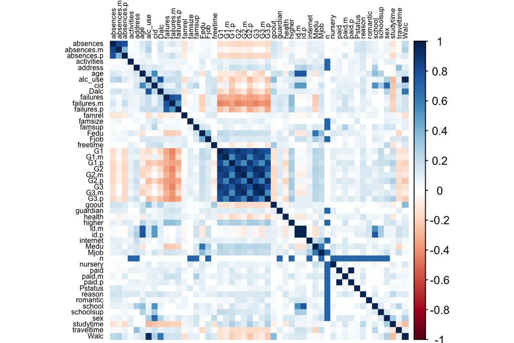

```r
library(corrplot)

cor.matrix <-
  mixed.cors %>%
  select(x, y, assoc) %>%
  spread(y, assoc) %>%
  select(-x) %>%
  replace(is.na(.), 0)

rownames(cor.matrix) <- colnames(cor.matrix)

corrplot(as.matrix(cor.matrix), method = "color",
         tl.cex = 0.5, tl.col = "black")
```

From the correlation plot, we see that, as expected by definition, `Dalc` and `Walc` correlate positively with `alc_use`. It would be interesting to include these for further analysis to explain the drinking behavior. Since we’re limited to four variables, we choose a coarse approach and only take `alc_use`.

The grade variables correlate negatively with `alc_use`; based on the data annotation in the beginning, it is easiest to choose `G3` for further analysis. The `famrel` correlates negatively with `alc_use`, and seems quite interesting. `goout`, `sex` and `studytime` are interesting as well. Let’s make sure these variables don’t correlate too much.

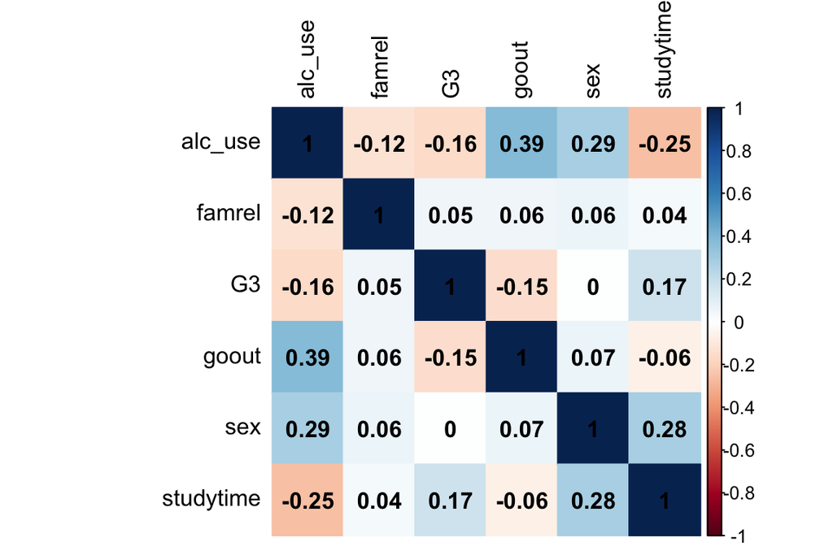

```r
interesting_vars <- c("alc_use", "G3", "famrel", "goout", "sex", "studytime")

cor.matrix <-
  alc %>%
    select(interesting_vars) %>%
    mixed_assoc(cor_method = "pearson") %>%
    select(x, y, assoc) %>%
    spread(y, assoc) %>%
    select(-x)

rownames(cor.matrix) <- colnames(cor.matrix)

corrplot(as.matrix(cor.matrix), method = "color",
         tl.cex = 1, tl.col = "black", addCoef.col = 'black')
```

Seems good!

```r
# Select the subset
alc.sub <- alc[, interesting_vars]

str(alc.sub)
```

```
## 'data.frame':    370 obs. of  6 variables:
##  $ alc_use  : num  1 3 1 1 2.5 1 2 2 2.5 1 ...
##  $ G3       : int  12 8 12 9 12 12 6 10 16 10 ...
##  $ famrel   : int  3 3 4 4 4 4 4 4 4 4 ...
##  $ goout    : int  2 4 1 2 1 2 2 3 2 3 ...
##  $ sex      : Factor w/ 2 levels "F","M": 1 1 1 1 1 1 1 1 1 1 ...
##  $ studytime: int  4 2 1 3 3 3 3 2 4 4 ...
```

## Further exploration

Begin with the GGally::ggpairs

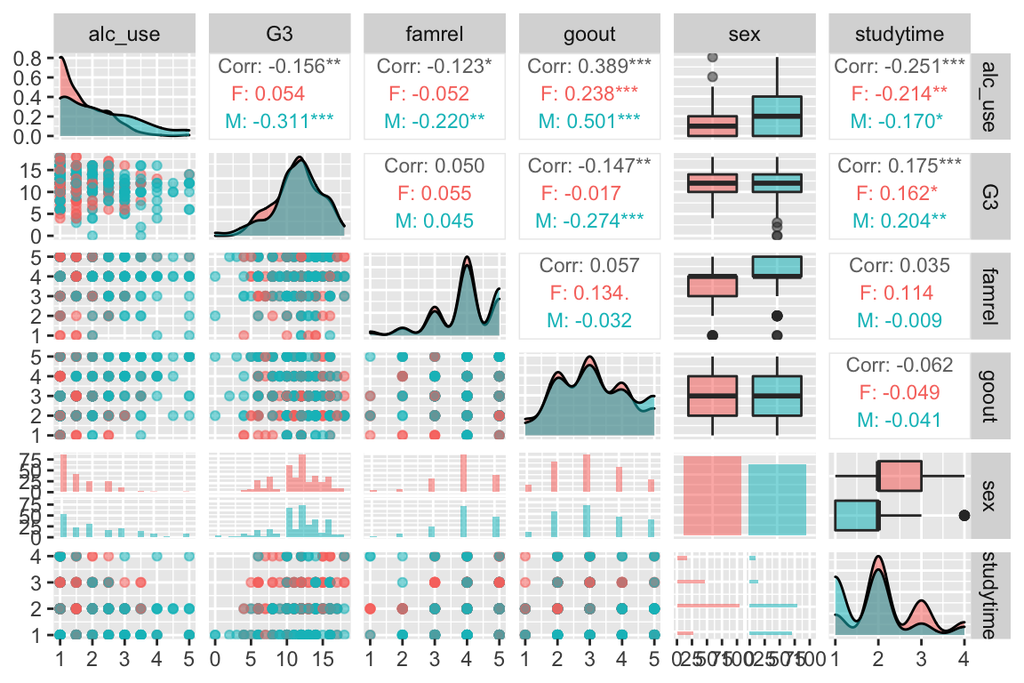

```r
library(GGally)
library(ggplot2)

p <- ggpairs(alc.sub, mapping = aes(col = sex, alpha = 0.3),
             lower = list(combo = wrap("facethist", bins = 20)),
             upper = list(continuous = wrap("cor", size = 3)))

p
```

We see that

- There is approximately equal number of males (n=175) and females (n=195)
- Males tend to use more alcohol
- Distribution of grade `G3` is similar for both sexes, and is not normal (by shapiro.test()), has a peak and is left skewed
- `famrel` correlates with `alc_use`, but significantly only for males
- Males report better quality family relationships
- Males use less time for studying
- `goout` correlates positively with alcohol use with a high significance
- `studytime` correlates negatively with alcohol use with a high significance

All in all, there are several hypotheses

- Getting a better grade while being male is associated with lower alcohol use
- Family relationships affect alcohol use
- Alcohol is used when going out
- Alcohol is not used when studying

Let’s take a closer look on the quality of family relationship versus alcohol use

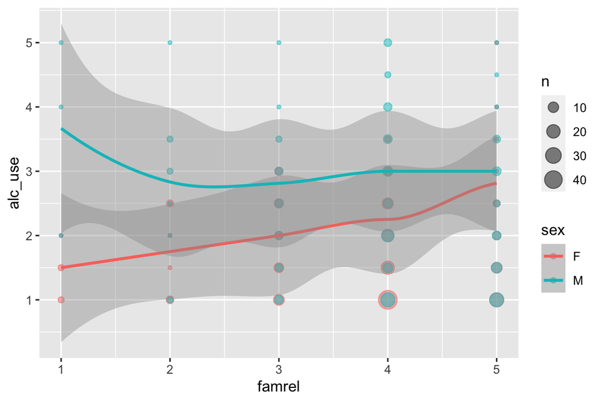

```r
library(tidyverse)

alc_var <- function(alc, expl.variable) {
  expl.vars <- c(expl.variable, "alc_use", "sex")

  # Tidyverse black magic
  res <-
    alc %>%
      select(one_of(expl.vars)) %>%
      count(!!!sapply(expl.vars, as.symbol))

  g <- ggplot(res, aes(x = .data[[expl.variable]], y = alc_use, col = sex)) +
    geom_point(aes(size = n), alpha = 0.5) + geom_smooth(method = "loess")

  return(g)
}

alc_var(alc, "famrel")
```

With a bit of caution, it appears than men with low quality `famrel` use more alcohol, as there is an increase in `alc_use` when `famrel` goes from medium to bad. However, the relationship is roughly linear (without deep analysis):

```r
summary(lm(alc_use ~ famrel, data = alc[alc$sex == "M", ]))
```

```
##
## Call:
## lm(formula = alc_use ~ famrel, data = alc[alc$sex == "M", ])
##
## Residuals:
##     Min      1Q  Median      3Q     Max
## -1.7458 -0.9118 -0.1898  0.8102  3.0882
##
## Coefficients:
##             Estimate Std. Error t value Pr(>|t|)
## (Intercept)  3.30184    0.38377   8.604 4.55e-15 ***
## famrel      -0.27800    0.09368  -2.968  0.00343 **
## ---
## Signif. codes:  0 '***' 0.001 '**' 0.01 '*' 0.05 '.' 0.1 ' ' 1
##
## Residual standard error: 1.128 on 173 degrees of freedom
## Multiple R-squared:  0.04844,    Adjusted R-squared:  0.04294
## F-statistic: 8.807 on 1 and 173 DF,  p-value: 0.003427
```

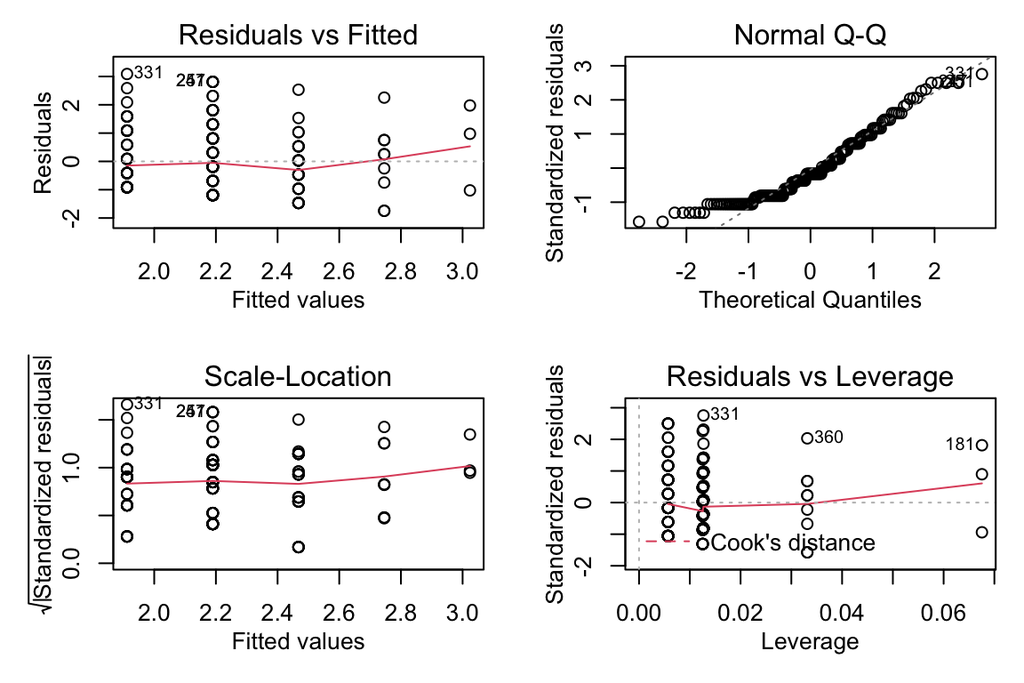

```r
# make the plot tighter
op <- par(mfrow=c(2, 2),
          mar = c(4, 4, 2, 1),
          mgp = c(2, 1, 0))

plot(lm(alc_use ~ famrel, data = alc[alc$sex == "M", ]))

par(op) # return original par
```

```r
library(car)
# There is no heteroscedasticity by Breusch-Pagan test
car::ncvTest(lm(alc_use ~ famrel, data = alc[alc$sex == "M", ]))
```

```
## Non-constant Variance Score Test
## Variance formula: ~ fitted.values
## Chisquare = 0.398195, Df = 1, p = 0.52802
```

Next, plot the other variables as well

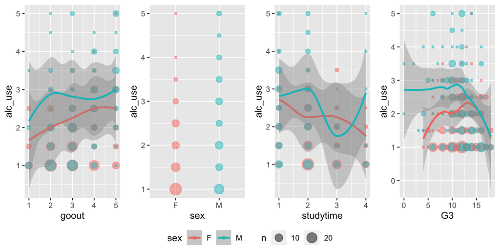

```r
library(ggpubr)

g1 <- alc_var(alc, "goout")
g2 <- alc_var(alc, "sex")
g3 <- alc_var(alc, "studytime")
g4 <- alc_var(alc, "G3")

ggarrange(g1, g2, g3, g4,
          ncol = 4, nrow = 1, common.legend = TRUE,
          legend = "bottom")
```

When `goout` increases, so does the alcohol use. Males appear to use more alcohol. As `studytime` increases, alcohol usage drops. `G3` does not have a clear linear pattern with alcohol use. Otherwise, the above hypotheses are OK.

## Logistic regression

Now we are ready to fit the logistic regression model with `G3`, `famrel`, `goout`, `sex` and `studytime`.

```r
model.1 <- glm(paste0("high_use", " ~ ", paste(interesting_vars[-1], collapse=" + ")),
               family = "binomial", data = alc)

summary(model.1)
```

```
##
## Call:
## glm(formula = paste0("high_use", " ~ ", paste(interesting_vars[-1],
##     collapse = " + ")), family = "binomial", data = alc)
##
## Deviance Residuals:
##     Min       1Q   Median       3Q      Max
## -1.6895  -0.7784  -0.4891   0.8155   2.6807
##
## Coefficients:
##             Estimate Std. Error z value Pr(>|z|)
## (Intercept) -0.85026    0.85893  -0.990  0.32222
## G3          -0.03667    0.04031  -0.910  0.36294
## famrel      -0.41604    0.13989  -2.974  0.00294 **
## goout        0.77038    0.12402   6.212 5.25e-10 ***
## sexM         0.80171    0.26695   3.003  0.00267 **
## studytime   -0.46034    0.17229  -2.672  0.00754 **
## ---
## Signif. codes:  0 '***' 0.001 '**' 0.01 '*' 0.05 '.' 0.1 ' ' 1
##
## (Dispersion parameter for binomial family taken to be 1)
##
##     Null deviance: 452.04  on 369  degrees of freedom
## Residual deviance: 369.86  on 364  degrees of freedom
## AIC: 381.86
##
## Number of Fisher Scoring iterations: 4
```

We got a model with four significant variables. `G3` is not significant, remove it and refit.

```r
model.2 <- glm(high_use ~ famrel + goout + sex + studytime,
               family = "binomial", data = alc)

summary(model.2)
```

```
##
## Call:
## glm(formula = high_use ~ famrel + goout + sex + studytime, family = "binomial",
##     data = alc)
##
## Deviance Residuals:
##     Min       1Q   Median       3Q      Max
## -1.5891  -0.7629  -0.4976   0.8304   2.6937
##
## Coefficients:
##             Estimate Std. Error z value Pr(>|z|)
## (Intercept)  -1.2672     0.7312  -1.733  0.08309 .
## famrel       -0.4193     0.1399  -2.996  0.00273 **
## goout         0.7873     0.1230   6.399 1.57e-10 ***
## sexM          0.7959     0.2669   2.982  0.00286 **
## studytime    -0.4814     0.1711  -2.814  0.00490 **
## ---
## Signif. codes:  0 '***' 0.001 '**' 0.01 '*' 0.05 '.' 0.1 ' ' 1
##
## (Dispersion parameter for binomial family taken to be 1)
##
##     Null deviance: 452.04  on 369  degrees of freedom
## Residual deviance: 370.69  on 365  degrees of freedom
## AIC: 380.69
##
## Number of Fisher Scoring iterations: 4
```

There is a lot of output

- Fitted model is $log \frac{Pr(high\_use =1)}{ 1 - Pr(high\_use = 1)} = log \frac{Pr(high\_use =1)}{Pr(high\_use = 0)} = -1.2672 - 0.4193*famrel + 0.7873 * goout + 0.7959 * sexM - 0.4814 * studytime$
- The coefficients represent a change in the log odds of the response when the explanatory variable increases by one, conditional on the other explanatory variables remaining constant
- All of the variables (and the non-zero intercept with 0.10 p-value cutoff) are significant by Wald test
- Deviance is similar in concept to the squared error in ordinary regression and quantifies difference between the observed and predicted proportions/probabilities
- Residual deviance is the sum of squares for residuals
- Null deviance is the deviance for null model (`high_use ~ 1`)
- AIC is the Akaike information criterion and can be used for model selection
- Number of Fisher Scoring iterations is related to how many iterations are need to fit the model

```r
# Residual deviance
sum(residuals(model.2, type = "deviance")^2)
```

```
## [1] 370.6854
```

See if residuals are roughly linear, otherwise we can’t use GLM.

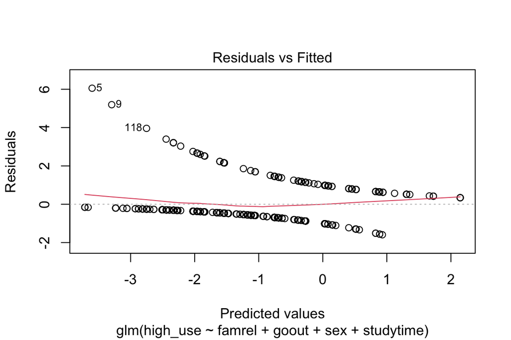

```r
# Plot residuals and check that linearity is OK
plot(model.2, which = 1)  # -> Looks OK.
```

We can also test with ANOVA if null model is significantly different from our model

```r
# see http://homepage.stat.uiowa.edu/~rdecook/stat3200/notes/LogReg_part2_4pp.pdf
# and https://cran.r-project.org/web/packages/HSAUR/vignettes/Ch_logistic_regression_glm.pdf
# and https://stats.stackexchange.com/questions/59879/

# 1-pchisq(model.2$null.deviance-model.2$deviance, model.2$df.null-model.2$df.residual)
null <- glm(high_use ~ 1, family = "binomial", data = alc)
anova(null, model.2, test="Chisq")
```

```
## Analysis of Deviance Table
##
## Model 1: high_use ~ 1
## Model 2: high_use ~ famrel + goout + sex + studytime
##   Resid. Df Resid. Dev Df Deviance  Pr(>Chi)
## 1       369     452.04
## 2       365     370.69  4   81.354 < 2.2e-16 ***
## ---
## Signif. codes:  0 '***' 0.001 '**' 0.01 '*' 0.05 '.' 0.1 ' ' 1
```

We conclude that at least one of the explanatory variables has non-zero coefficient by this test.

### Compute odds ratios and confidence intervals

```r
OR <- coef(model.2) %>% exp
CI <- confint(model.2) %>% exp

list(OR = OR, CI = CI)
```

```
## $OR
## (Intercept)      famrel       goout        sexM   studytime
##   0.2816141   0.6575181   2.1974324   2.2165443   0.6179355
##
## $CI
##                  2.5 %    97.5 %
## (Intercept) 0.06545486 1.1622100
## famrel      0.49791884 0.8636137
## goout       1.73873662 2.8198312
## sexM        1.31841735 3.7630180
## studytime   0.43751933 0.8576353
```

The odds ratio for `famrel` is 0.66 and 95% CI is [0.50, 0.86]. Thus, increase by 1 unit in `famrel` is associated with a decrease in the odds of `high_use` by 14-50%.

Variables `goout` (increases `high_use` odds) and `studytime` (decreases `high_use` odds) are interpreted analogously and neither containts 1 in the 95% CI.

The `sexM` is interpreted in relation to implicit `sexF`: being male increases the `high_use` odds by around 122% with 95% CI of [1.32, 3.76].

It seems that the results correspond to the hypotheses. It feels like `famrel` would require more work although the interaction term of `sex`*`famrel` is not significant when added to `model.2` (data not shown).

## Predictive power

```r
observed <- alc$high_use
predicted <- predict(model.2, type = "response") > 0.5

# 2x2 tabulation, confusion matrix
table(observed, predicted)
```

```
##         predicted
## observed FALSE TRUE
##    FALSE   230   29
##    TRUE     59   52
```

Most cases are classified correctly.

Below are the predictions versus actual `high_use` values, plotted separately for each explanatory variable.

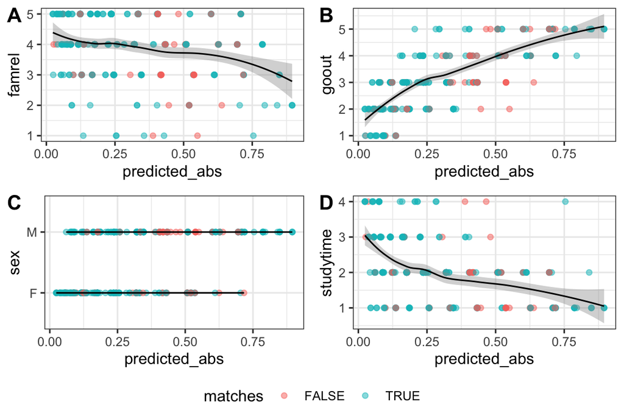

```r
# Get predictions, compare against true values
predicted_abs <- predict(model.2, type = "response")

df <- data.frame(cbind(observed, predicted, predicted_abs,
                       alc[, interesting_vars[3:6]]))

df$matches <- df$observed == df$predicted

# Plot by explanatory variables
prob.expl <- function(df, ind.var, expl.var, col.var) {

  g <- ggplot(df, aes(x = .data[[ind.var]],
                      y = .data[[expl.var]])) +
    geom_point(alpha = 0.5, aes(col = .data[[col.var]])) +
    geom_smooth(method = "loess", col = "black", size = 0.5) +
    theme_bw()
  g
}

g1 <- prob.expl(df, "predicted_abs", "famrel", "matches")
g2 <- prob.expl(df, "predicted_abs", "goout", "matches")
g3 <- prob.expl(df, "predicted_abs", "sex", "matches")
g4 <- prob.expl(df, "predicted_abs", "studytime", "matches")

ggarrange(g1, g2, g3, g4, ncol = 2, nrow = 2, labels = c("A", "B", "C", "D"),
          common.legend = TRUE, legend = "bottom")
```

From the plot above we see where the predictions of `high_use`are right (greenish points) and wrong (red points). For `famrel` (A), `sex` (C) and `studytime` (D), the predictions seem to be false mostly around probability 0.5. With `goout`, `high_use` appears to be poorly predicted when `goout` is low and predicted value is in the range of [0.5, 0.7].

Quantify at which probability values mismatches tend to occur:

```r
# Predictions equal observation
round(table(cut_interval(df[df$matches == TRUE, c("predicted_abs")], length=0.20)) /
  length(df$matches), 2)
```

```
##
##   [0,0.2] (0.2,0.4] (0.4,0.6] (0.6,0.8]   (0.8,1]
##      0.36      0.22      0.08      0.08      0.02
```

```r
# False predictions
round(table(cut_interval(df[df$matches == FALSE, c("predicted_abs")], length=0.20)) /
  length(df$matches), 2)
```

```
##
##   [0,0.2] (0.2,0.4] (0.4,0.6] (0.6,0.8]
##      0.06      0.05      0.10      0.03
```

This confirms that most false predictions are made around the probability 0.5.

The training error of the model is 0.24, i.e. lowish. If we just guessed using, say, `goout`, the error would be around 0.28, which is not very bad. Of course the guessing is not very random, since we already know that `goout` is an important predictor.

```r
# Training error, model.2
sum(df$matches == FALSE) / length(df$matches)
```

```
## [1] 0.2378378
```

```r
# Guess high_use by goout
guesses <- rep(FALSE, times = nrow(df))
guesses[df$goout > mean(df$goout)] <- TRUE

table(df$observed, guesses)
```

```
##        guesses
##         FALSE TRUE
##   FALSE   198   61
##   TRUE     41   70
```

```r
sum(guesses != df$observed) / nrow(df)
```

```
## [1] 0.2756757
```

## Cross-validation

Follow the code in DataCamp for this one

```r
# define a loss function (average prediction error)
loss_func <- function(class, prob) {
  n_wrong <- abs(class - prob) > 0.5
  mean(n_wrong)
}

# compute the average number of wrong predictions in the (training) data
loss_func(alc$high_use, df$predicted_abs)
```

```
## [1] 0.2378378
```

```r
# K-fold cross-validation
library(boot)
cv <- cv.glm(data = alc, cost = loss_func, glmfit = model.2, K = 10)

# average number of wrong predictions in the cross validation
cv$delta[1]
```

```
## [1] 0.2540541
```

The test set performance is a bit better than the DataCamp baseline, 0.25 versus 0.26.

## Simple model selection

```r
# Select all explanatory variables available
training.vars <- colnames(alc)[1:36] # Discard non-joined .m and .p variables

# Discard alcohol consumption variables and technical variables
training.vars <- training.vars[!(
  training.vars %in% c("Dalc", "Walc", "n", "id.p", "id.m"))]
```

Now, with enough compute we could just try all the variables, but that would amount to 2^32 = 4294967296 models. We instead use stepwise selection by AIC starting with the full model and progressing backwards. We also assume R handles the factor variable to dummy (treatment) encoding. (Note the [problems](https://journalofbigdata.springeropen.com/articles/10.1186/s40537-018-0143-6) of stepwise regression. It would be advisable to use other methods e.g. through Caret.)

```r
library(MASS)

# Run stepwise AIC selection on full model, keep the model and its AIC
final.m <- stepAIC(
  # Full model
  glm(paste0("high_use", " ~ ", paste(training.vars[-1], collapse=" + ")),
             family = binomial, data = alc),
  direction = "backward", trace = FALSE,
  # What to keep from models
  keep = function(model, aic) { list(model = model, aic = aic) } )
```

Then perform 10-fold CV for the models

```r
# Init
CVs  <- rep(NULL, ncol(final.m$keep))  # Test error
ERRs <- rep(NULL, ncol(final.m$keep))  # Train error
AICs <- rep(NULL, ncol(final.m$keep))
Nvar <- rep(NULL, ncol(final.m$keep))

for (i in 1:ncol(final.m$keep)) {  # Each column is a model

  interim.m <- final.m$keep[, i][1]$model
  CVs[i] <- cv.glm(data = alc, cost = loss_func, glmfit = interim.m, K = 10)$delta[1]

  ERRs[i] <- loss_func(alc$high_use, predict(interim.m, type = "response"))

  AICs[i] <- final.m$keep[, i][2]$aic

  Nvar[i] <- length(final.m$keep[, i][1]$model$coefficients) - 1
}

CV.res <- data.frame(test = CVs, train = ERRs, AIC = AICs, Nvar = Nvar)
```

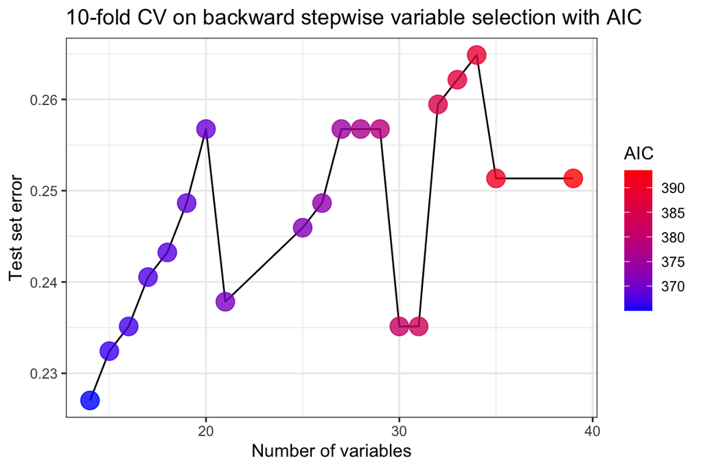

```r
# Somewhat unsatisfactory graph with points

g1 <- ggplot(CV.res, aes(x = Nvar, y = test)) + geom_line() +
  geom_point(aes(x = Nvar, y = test, color = AIC), size = 5, alpha = 0.8) +
  theme_bw() +  xlab("Number of variables") + ylab("Test set error") +
  ggtitle("10-fold CV on backward stepwise variable selection with AIC") +
  scale_color_gradient(low="blue", high="red")

g1
```

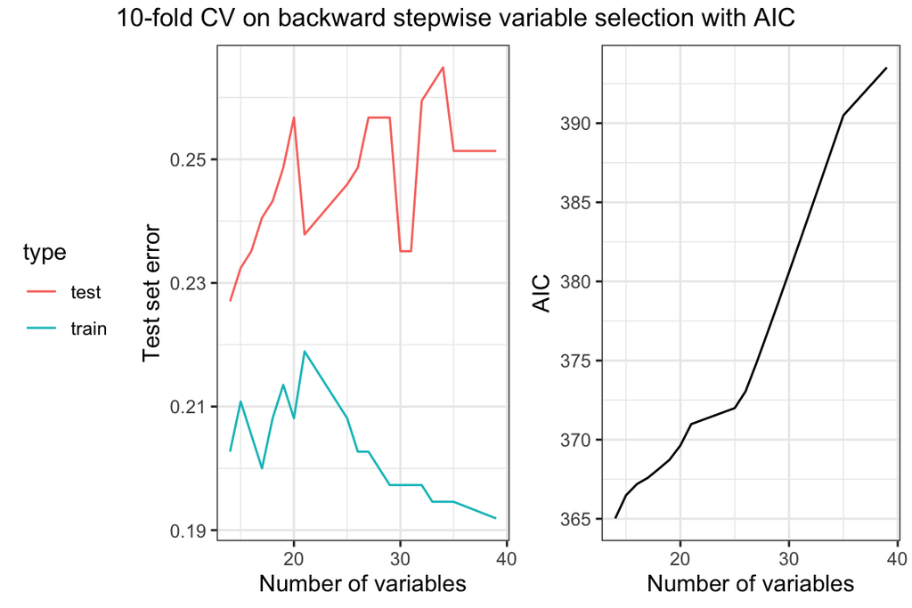

```r
# Better graph with both test and training error, and AIC separately

errors <- gather(CV.res, type, error, c("test", "train"))

g1 <- ggplot(errors, aes(x = Nvar, color = type)) + geom_line(aes(y = error)) +
  theme_bw() +  xlab("Number of variables") + ylab("Test set error")

g2 <- ggplot(errors, aes(x = Nvar)) + geom_line(aes(y = AIC)) +
  theme_bw() +  xlab("Number of variables") + ylab("AIC")

g <- ggarrange(g1, g2, ncol = 2, nrow = 1, widths = c(2, 1.5),
          common.legend = FALSE, legend = "left")

annotate_figure(g, top = text_grob("10-fold CV on backward stepwise variable selection with AIC"))
```

The final model was

```r
summary(final.m)
```

```
##
## Call:
## glm(formula = high_use ~ sex + address + famsize + reason + guardian +
##     activities + romantic + famrel + goout + health + absences,
##     family = binomial, data = alc)
##
## Deviance Residuals:
##     Min       1Q   Median       3Q      Max
## -1.8167  -0.7154  -0.4262   0.5635   2.7612
##
## Coefficients:
##                  Estimate Std. Error z value Pr(>|z|)
## (Intercept)      -2.14937    0.86318  -2.490 0.012772 *
## sexM              0.98275    0.28722   3.422 0.000623 ***
## addressU         -0.89491    0.33661  -2.659 0.007847 **
## famsizeLE3        0.47009    0.29971   1.569 0.116759
## reasonhome        0.31183    0.35612   0.876 0.381229
## reasonother       1.24517    0.47895   2.600 0.009328 **
## reasonreputation -0.28654    0.36969  -0.775 0.438278
## guardianmother   -0.68303    0.32428  -2.106 0.035179 *
## guardianother     0.41726    0.71637   0.582 0.560256
## activitiesyes    -0.51481    0.28383  -1.814 0.069710 .
## romanticyes      -0.50684    0.30464  -1.664 0.096171 .
## famrel           -0.50627    0.15580  -3.249 0.001156 **
## goout             0.91148    0.13829   6.591 4.36e-11 ***
## health            0.16738    0.10359   1.616 0.106138
## absences          0.09152    0.02373   3.856 0.000115 ***
## ---
## Signif. codes:  0 '***' 0.001 '**' 0.01 '*' 0.05 '.' 0.1 ' ' 1
##
## (Dispersion parameter for binomial family taken to be 1)
##
##     Null deviance: 452.04  on 369  degrees of freedom
## Residual deviance: 335.02  on 355  degrees of freedom
## AIC: 365.02
##
## Number of Fisher Scoring iterations: 5
```

```r
parsimonious.m <- glm(formula = high_use ~ sex + address + reason + guardian +
    activities + famrel + goout + absences, family = binomial, data = alc)

summary(parsimonious.m)
```

```
##
## Call:
## glm(formula = high_use ~ sex + address + reason + guardian +
##     activities + famrel + goout + absences, family = binomial,
##     data = alc)
##
## Deviance Residuals:
##     Min       1Q   Median       3Q      Max
## -1.8386  -0.7558  -0.4676   0.6257   2.8133
##
## Coefficients:
##                  Estimate Std. Error z value Pr(>|z|)
## (Intercept)      -1.65723    0.77828  -2.129 0.033225 *
## sexM              1.09542    0.27999   3.912 9.14e-05 ***
## addressU         -0.84765    0.33097  -2.561 0.010435 *
## reasonhome        0.24841    0.34895   0.712 0.476533
## reasonother       1.06110    0.46814   2.267 0.023412 *
## reasonreputation -0.35044    0.36541  -0.959 0.337531
## guardianmother   -0.65433    0.31871  -2.053 0.040071 *
## guardianother     0.27975    0.69303   0.404 0.686459
## activitiesyes    -0.55234    0.28067  -1.968 0.049075 *
## famrel           -0.45739    0.15011  -3.047 0.002311 **
## goout             0.87831    0.13550   6.482 9.06e-11 ***
## absences          0.08739    0.02335   3.743 0.000182 ***
## ---
## Signif. codes:  0 '***' 0.001 '**' 0.01 '*' 0.05 '.' 0.1 ' ' 1
##
## (Dispersion parameter for binomial family taken to be 1)
##
##     Null deviance: 452.04  on 369  degrees of freedom
## Residual deviance: 341.90  on 358  degrees of freedom
## AIC: 365.9
##
## Number of Fisher Scoring iterations: 5
```

```r
loss_func(alc$high_use, predict(parsimonious.m, type = "response"))
```

```
## [1] 0.1972973
```

```r
cv.glm(data = alc, cost = loss_func, glmfit = parsimonious.m, K = 10)$delta[1]
```

```
## [1] 0.2297297
```

# Week 4 - Clustering and classification

```r
date()
```

```
## [1] "Sat Dec 11 23:11:22 2021"
```

## Introduction

This week, we are analyzing and modeling a dataset from MASS package, “Housing Values in Suburbs of Boston”. References and further description can be found [here](https://stat.ethz.ch/R-manual/R-devel/library/MASS/html/Boston.html).

## Dataset

```r
rm(list=ls())

library(MASS)
boston <- MASS::Boston

dim(boston)
```

```
## [1] 506  14
```

The data hase 506 rows and 14 columns.

```r
str(boston)
```

```
## 'data.frame':    506 obs. of  14 variables:
##  $ crim   : num  0.00632 0.02731 0.02729 0.03237 0.06905 ...
##  $ zn     : num  18 0 0 0 0 0 12.5 12.5 12.5 12.5 ...
##  $ indus  : num  2.31 7.07 7.07 2.18 2.18 2.18 7.87 7.87 7.87 7.87 ...
##  $ chas   : int  0 0 0 0 0 0 0 0 0 0 ...
##  $ nox    : num  0.538 0.469 0.469 0.458 0.458 0.458 0.524 0.524 0.524 0.524 ...
##  $ rm     : num  6.58 6.42 7.18 7 7.15 ...
##  $ age    : num  65.2 78.9 61.1 45.8 54.2 58.7 66.6 96.1 100 85.9 ...
##  $ dis    : num  4.09 4.97 4.97 6.06 6.06 ...
##  $ rad    : int  1 2 2 3 3 3 5 5 5 5 ...
##  $ tax    : num  296 242 242 222 222 222 311 311 311 311 ...
##  $ ptratio: num  15.3 17.8 17.8 18.7 18.7 18.7 15.2 15.2 15.2 15.2 ...
##  $ black  : num  397 397 393 395 397 ...
##  $ lstat  : num  4.98 9.14 4.03 2.94 5.33 ...
##  $ medv   : num  24 21.6 34.7 33.4 36.2 28.7 22.9 27.1 16.5 18.9 ...
```

Most of the columns are double valued, `chas` and `rad` are integer typed.

```r
table(sapply(boston, typeof))
```

```
##
##  double integer
##      12       2
```

Summary on the variables is shown below. `crim` is per capita crime rate by town, `tax` is a tax rate. `chas` is a dummy variable describing relative location to Charles River (1 if tract bounds river). Full descriptions are [here](https://stat.ethz.ch/R-manual/R-devel/library/MASS/html/Boston.html).

```r
summary(boston)
```

```
##       crim                zn             indus            chas
##  Min.   : 0.00632   Min.   :  0.00   Min.   : 0.46   Min.   :0.00000
##  1st Qu.: 0.08205   1st Qu.:  0.00   1st Qu.: 5.19   1st Qu.:0.00000
##  Median : 0.25651   Median :  0.00   Median : 9.69   Median :0.00000
##  Mean   : 3.61352   Mean   : 11.36   Mean   :11.14   Mean   :0.06917
##  3rd Qu.: 3.67708   3rd Qu.: 12.50   3rd Qu.:18.10   3rd Qu.:0.00000
##  Max.   :88.97620   Max.   :100.00   Max.   :27.74   Max.   :1.00000
##       nox               rm             age              dis
##  Min.   :0.3850   Min.   :3.561   Min.   :  2.90   Min.   : 1.130
##  1st Qu.:0.4490   1st Qu.:5.886   1st Qu.: 45.02   1st Qu.: 2.100
##  Median :0.5380   Median :6.208   Median : 77.50   Median : 3.207
##  Mean   :0.5547   Mean   :6.285   Mean   : 68.57   Mean   : 3.795
##  3rd Qu.:0.6240   3rd Qu.:6.623   3rd Qu.: 94.08   3rd Qu.: 5.188
##  Max.   :0.8710   Max.   :8.780   Max.   :100.00   Max.   :12.127
##       rad              tax           ptratio          black
##  Min.   : 1.000   Min.   :187.0   Min.   :12.60   Min.   :  0.32
##  1st Qu.: 4.000   1st Qu.:279.0   1st Qu.:17.40   1st Qu.:375.38
##  Median : 5.000   Median :330.0   Median :19.05   Median :391.44
##  Mean   : 9.549   Mean   :408.2   Mean   :18.46   Mean   :356.67
##  3rd Qu.:24.000   3rd Qu.:666.0   3rd Qu.:20.20   3rd Qu.:396.23
##  Max.   :24.000   Max.   :711.0   Max.   :22.00   Max.   :396.90
##      lstat            medv
##  Min.   : 1.73   Min.   : 5.00
##  1st Qu.: 6.95   1st Qu.:17.02
##  Median :11.36   Median :21.20
##  Mean   :12.65   Mean   :22.53
##  3rd Qu.:16.95   3rd Qu.:25.00
##  Max.   :37.97   Max.   :50.00
```

Correlation plot shows many strong correlations (without going into p-values):

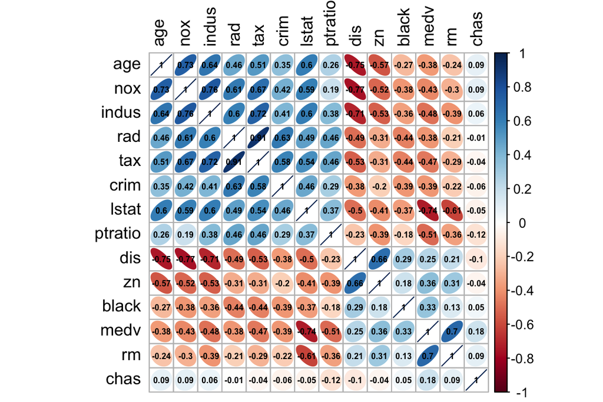

```r
library(corrplot)
library(tidyverse)

cor.matrix <- cor(boston)

rownames(cor.matrix) <- colnames(cor.matrix)

corrplot(as.matrix(cor.matrix), method = "ellipse",
         order = "AOE", number.cex = 0.5,  # Use some nice ordering
         tl.cex = 1, tl.col = "black", addCoef.col = 'black')
```

We can filter and show correlations whose absolute value is above 0.7. Only show significant correlation coefficients. We see that e.g. `dis` and `age` correlate negatively, while `nox` and `age` correlate positively.

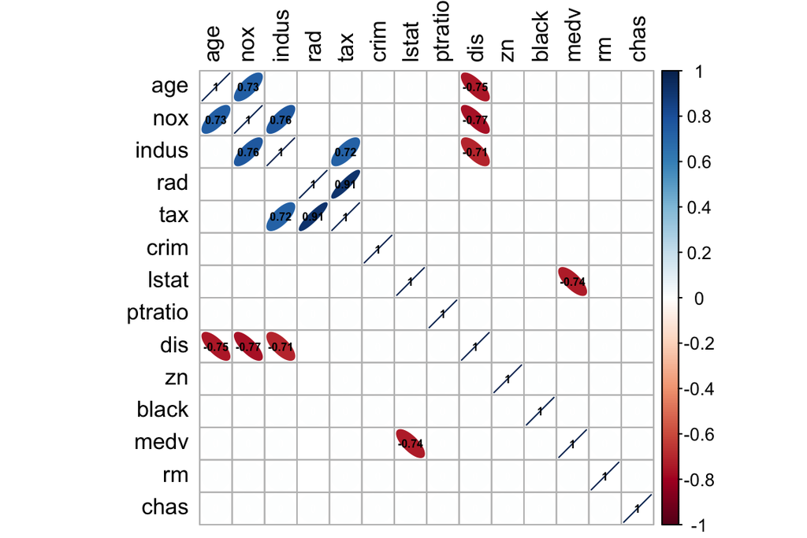

```r
cor.matrix.filtered <- cor(boston)

cor.matrix.filtered <- apply(cor.matrix.filtered, 2, function(x) {
  ifelse(abs(x) > 0.7, x, 0)
})

rownames(cor.matrix.filtered) <- colnames(cor.matrix.filtered)

# Don't show zeroes. Get the order manually to match that above.
ord <- corrMatOrder(cor.matrix, order="AOE")

cor.matrix.filtered <- cor.matrix.filtered[ord, ord]
col <- ifelse(abs(cor.matrix.filtered - 0) < .Machine$double.eps, "white", "black") #[ord, ord]

# Test for correlation significance.
testRes = cor.mtest(boston, conf.level = 0.95)

corrplot(as.matrix(cor.matrix.filtered),
         method = "ellipse", order = "original", number.cex = 0.5,
         tl.cex = 1, tl.col = "black",
         p.mat = testRes$p, insig = "blank", na.label = " ",
         use = "complete.obs", addCoef.col = col)
```

Plot the variables that correlate highly with some other variable

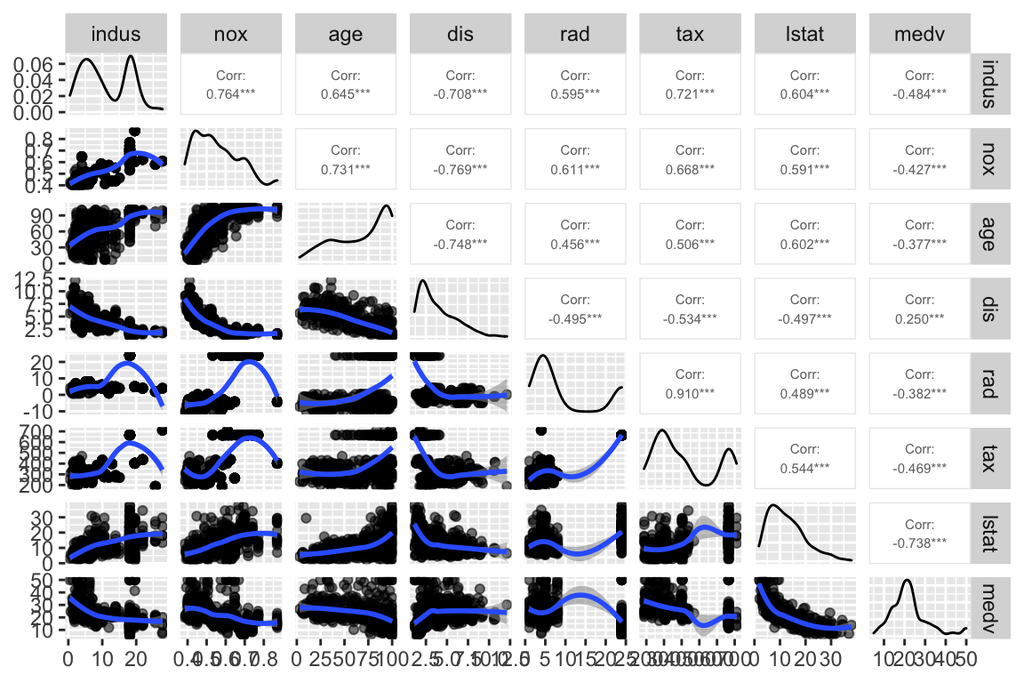

```r
interesting <- which(
  abs(cor.matrix.filtered) > 0.7 & abs(cor.matrix.filtered) < 1,
  arr.ind = TRUE)

boston.cor <- boston[, which(
  colnames(boston) %in% rownames(interesting))]

# pairs(boston.cor, col = boston$chas)

library(GGally)

lower <- function(data, mapping, method="loess", ...){
      p <- ggplot(data = data, mapping = mapping) +
      geom_point() +
      geom_smooth(method=method, ...)
      p
}

p <- ggpairs(boston.cor, mapping = aes(alpha = 0.3),
             lower = list(continuous = lower),
             upper = list(continuous = wrap("cor", size = 2)))

p
```

We see that e.g. `nox` and `age` have a clear non-linear pattern (modeling with lm reveals heteroscedasticity of the residuals vs. fitted values). Other variables produce two groups of points with `rad` or `tax`.

Then plot the other ones that do not correlate strongly.

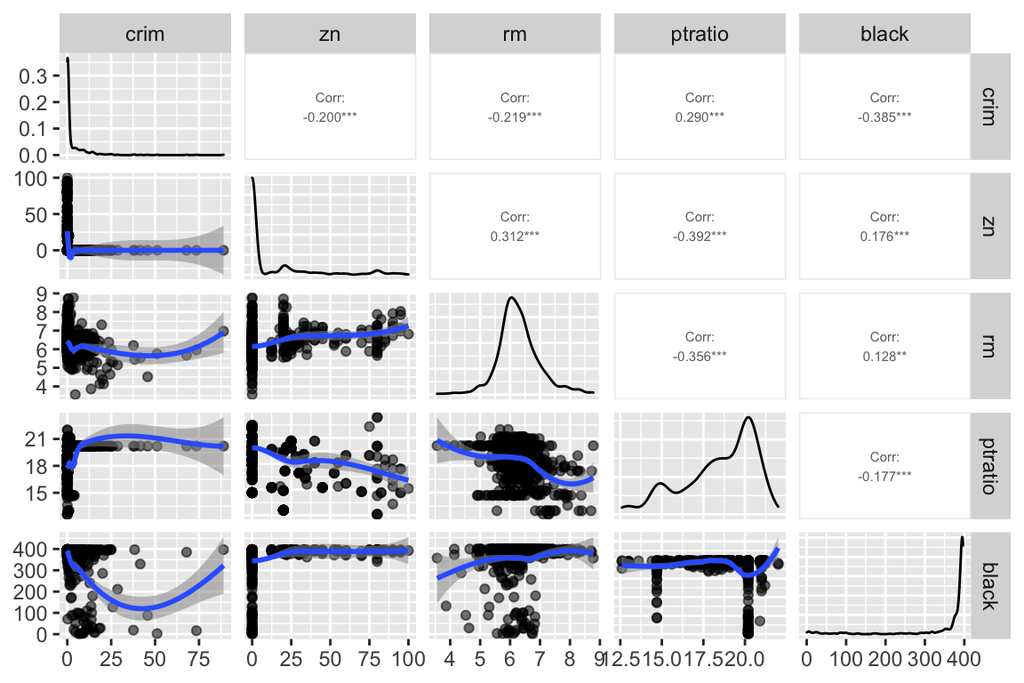

```r
boston.cor <- boston[, which(!  # not
  colnames(boston) %in% c(rownames(interesting), "chas"))]

# c("nox", "dis", "tax", "indus", "age", "rad", "medv", "lstat")

# pairs(boston.cor, col = boston$chas)

lower <- function(data, mapping, method="loess", ...){
      p <- ggplot(data = data, mapping = mapping) +
      geom_point() +
      geom_smooth(method=method, ...)
      p
}

p <- ggpairs(boston.cor, mapping = aes(alpha = 0.3),
             lower = list(continuous = lower),
             upper = list(continuous = wrap("cor", size = 2)))

p
```

Here we also see some interesting patterns, which are left for future analyses.

Then plot variable distributions, stratify by binary `chas`

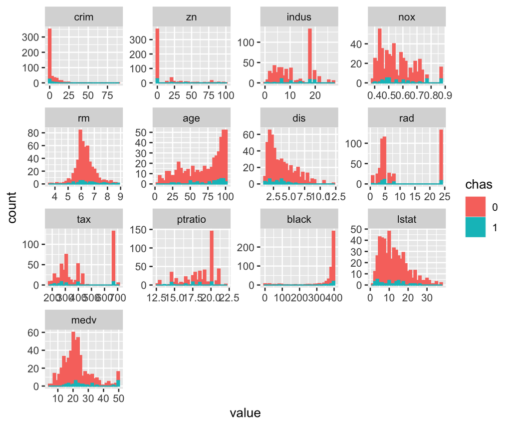

```r
library(reshape2)

boston$chas <- as.factor(boston$chas)

boston.m <-
  boston %>%
    melt(id.vars = c("chas"))

ggplot(boston.m, aes(value, col = chas)) +
  geom_histogram(aes(fill = chas)) + facet_wrap(~variable, scales = "free")
```

Most of the distributions are not close to normal, and most observations belong to `chas == 0` class. Distributions of `indus`, `tax` and `rad` have two peaks.

## Standardization

```r
boston.std <- as.data.frame(
  scale(boston[, which(!(colnames(boston) %in% c("chas")))]))

boston.std$chas <- boston$chas

summary(boston.std)
```

```
##       crim                 zn               indus              nox
##  Min.   :-0.419367   Min.   :-0.48724   Min.   :-1.5563   Min.   :-1.4644
##  1st Qu.:-0.410563   1st Qu.:-0.48724   1st Qu.:-0.8668   1st Qu.:-0.9121
##  Median :-0.390280   Median :-0.48724   Median :-0.2109   Median :-0.1441
##  Mean   : 0.000000   Mean   : 0.00000   Mean   : 0.0000   Mean   : 0.0000
##  3rd Qu.: 0.007389   3rd Qu.: 0.04872   3rd Qu.: 1.0150   3rd Qu.: 0.5981
##  Max.   : 9.924110   Max.   : 3.80047   Max.   : 2.4202   Max.   : 2.7296
##        rm               age               dis               rad
##  Min.   :-3.8764   Min.   :-2.3331   Min.   :-1.2658   Min.   :-0.9819
##  1st Qu.:-0.5681   1st Qu.:-0.8366   1st Qu.:-0.8049   1st Qu.:-0.6373
##  Median :-0.1084   Median : 0.3171   Median :-0.2790   Median :-0.5225
##  Mean   : 0.0000   Mean   : 0.0000   Mean   : 0.0000   Mean   : 0.0000
##  3rd Qu.: 0.4823   3rd Qu.: 0.9059   3rd Qu.: 0.6617   3rd Qu.: 1.6596
##  Max.   : 3.5515   Max.   : 1.1164   Max.   : 3.9566   Max.   : 1.6596
##       tax             ptratio            black             lstat
##  Min.   :-1.3127   Min.   :-2.7047   Min.   :-3.9033   Min.   :-1.5296
##  1st Qu.:-0.7668   1st Qu.:-0.4876   1st Qu.: 0.2049   1st Qu.:-0.7986
##  Median :-0.4642   Median : 0.2746   Median : 0.3808   Median :-0.1811
##  Mean   : 0.0000   Mean   : 0.0000   Mean   : 0.0000   Mean   : 0.0000
##  3rd Qu.: 1.5294   3rd Qu.: 0.8058   3rd Qu.: 0.4332   3rd Qu.: 0.6024
##  Max.   : 1.7964   Max.   : 1.6372   Max.   : 0.4406   Max.   : 3.5453
##       medv         chas
##  Min.   :-1.9063   0:471
##  1st Qu.:-0.5989   1: 35
##  Median :-0.1449
##  Mean   : 0.0000
##  3rd Qu.: 0.2683
##  Max.   : 2.9865
```

```r
apply(boston.std, 2, var)
```

```
##       crim         zn      indus        nox         rm        age        dis
## 1.00000000 1.00000000 1.00000000 1.00000000 1.00000000 1.00000000 1.00000000
##        rad        tax    ptratio      black      lstat       medv       chas
## 1.00000001 1.00000000 1.00000000 1.00000000 1.00000000 1.00000000 0.06451297
```

All variables except the factorized `chas` are mean centered, and have unit variance. Plot the distributions for clarity

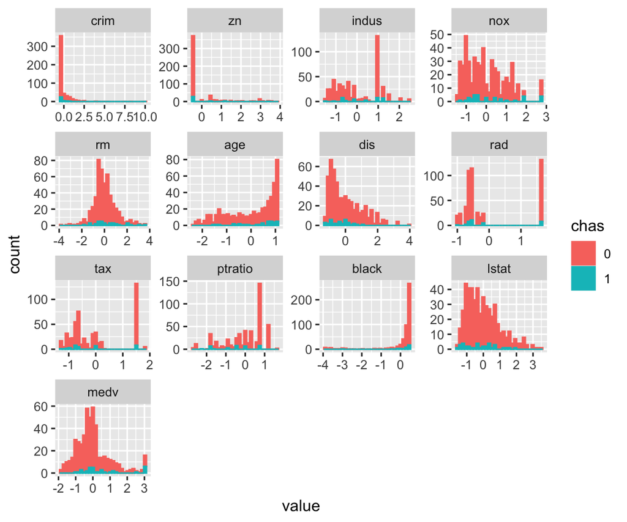

```r
boston.m <-
  boston.std %>%
    melt(id.vars = c("chas"))

ggplot(boston.m, aes(value, col = chas)) +
  geom_histogram(aes(fill = chas)) + facet_wrap(~variable, scales = "free")
```

Create categorical variable of crime rate by quantiles

```r
bins <- quantile(boston.std$crim)

crime <- cut(boston.std$crim, breaks = bins,
             include.lowest = TRUE,
             labels = c("low", "med_low", "med_high", "high"))

boston.std <- dplyr::select(boston.std, -crim)

boston.std$crime <- crime
```

Divide into train and test set (follow course’s Datacamp exercise)

```r
# standardize the chas as we need later
boston.std$chas <- scale(as.numeric(boston.std$chas))

n <- nrow(boston.std)

set.seed(123)  # for reproducibility
# sample n * 0.8 entries from 1:n
ind <- sample(n,  size = n * 0.8)

train <- boston.std[ind,]
test <- boston.std[-ind,]

# save the correct classes from test data
test.correct.classes <- test$crime

# remove the crime variable from test data
test <- dplyr::select(test, -crime)
```